# Question 1 - Part B

- Yes this model does suffer from multicollinearity as Vehicle_Class (39.901), Monthly_Premium_Auto (38.866), Coverage (7.726), and Total_Claim_Amount (5.242) all have VIF numbers greater than 5.
- The log-liklihood of this model is **-240.018**.

```r
result <- logistic(
  InsuranceRenewalTrain,
  rvar = "Response",
  evar = c(
    "State", "Coverage",
    "Location_Code", "Monthly_Premium_Auto",
    "Months_Since_Last_Claim",
    "Months_Since_Policy_Inception",
    "Number_of_Open_Complaints",
    "Number_of_Policies",
    "Policy", "Sales_Channel",
    "Total_Claim_Amount",
    "Vehicle_Class", "Vehicle_Size",
    "Renew_Offer"
  ),
  lev = "1"
)
summary(result, sum_check = "vif")
```

```
Logistic regression (GLM)
Data                 : InsuranceRenewalTrain
Response variable    : Response
Level                : 1 in Response
Explanatory variables: State, Coverage, Location_Code, Monthly_Premium_Auto, Months_Since_Last_Claim, Months_Since_Policy_Inception, Number_of_Open_Complaints, Number_of_Policies, Policy, Sales_Channel, Total_Claim_Amount, Vehicle_Class, Vehicle_Size, Renew_Offer
Null hyp.: there is no effect of x on Response
Alt. hyp.: there is an effect of x on Response

                                   OR      OR% coefficient std.error z.value p.value
 (Intercept)                                        -3.890     1.556  -2.499   0.012 *
 State|California               0.948    -5.2%      -0.054     0.360  -0.149   0.881
 State|Nevada                   0.831   -16.9%      -0.185     0.507  -0.365   0.715
 State|Oregon                   0.797   -20.3%      -0.227     0.368  -0.618   0.537
 State|Washington               0.912    -8.8%      -0.092     0.497  -0.185   0.854
 Coverage|Extended              0.997    -0.3%      -0.003     0.482  -0.007   0.995
 Coverage|Premium               1.270    27.0%       0.239     0.910   0.263   0.793
 Location_Code|Suburban        41.252 4,025.2%       3.720     0.657   5.663  < .001 ***
 Location_Code|Urban            2.950   195.0%       1.082     0.720   1.503   0.133
 Monthly_Premium_Auto           1.011     1.1%       0.011     0.018   0.569   0.569
 Months_Since_Last_Claim        0.973    -2.7%      -0.027     0.013  -2.155   0.031 *
 Months_Since_Policy_Inception  0.996    -0.4%      -0.004     0.004  -0.811   0.417
 Number_of_Open_Complaints      0.987    -1.3%      -0.014     0.136  -0.099   0.921
 Number_of_Policies             0.890   -11.0%      -0.117     0.055  -2.132   0.033 *
 Policy|Corporate L2            1.372    37.2%       0.316     0.828   0.382   0.702
 Policy|Corporate L3            1.301    30.1%       0.263     0.755   0.348   0.728
 Policy|Personal L1             1.238    23.8%       0.213     0.732   0.291   0.771
 Policy|Personal L2             0.564   -43.6%      -0.573     0.747  -0.767   0.443
 Policy|Personal L3             1.283    28.3%       0.249     0.698   0.357   0.721
 Policy|Special L1              2.043   104.3%       0.714     1.189   0.601   0.548
 Policy|Special L2              0.000  -100.0%     -15.011   703.921  -0.021   0.983
 Policy|Special L3              5.691   469.1%       1.739     0.973   1.787   0.074 .
 Sales_Channel|Branch           0.593   -40.7%      -0.522     0.303  -1.721   0.085 .
 Sales_Channel|Call Center      0.301   -69.9%      -1.202     0.429  -2.805   0.005 **
 Sales_Channel|Web              1.899    89.9%       0.641     0.380   1.688   0.091 .
 Total_Claim_Amount             0.994    -0.6%      -0.006     0.001  -4.821  < .001 ***
 Vehicle_Class|Luxury Car      18.706 1,770.6%       2.929     2.499   1.172   0.241
 Vehicle_Class|Luxury SUV      22.579 2,157.9%       3.117     2.666   1.169   0.242
 Vehicle_Class|Sports Car       1.458    45.8%       0.377     1.010   0.374   0.709
 Vehicle_Class|SUV              1.868    86.8%       0.625     0.851   0.734   0.463
 Vehicle_Class|Two-Door Car     0.733   -26.7%      -0.310     0.347  -0.892   0.372
```

[output cut: 12 more lines]

```
                                 VIF   Rsq
Vehicle_Class                 39.901 0.975
Monthly_Premium_Auto          38.866 0.974
Coverage                       7.726 0.871
Total_Claim_Amount             5.242 0.809
Location_Code                  3.112 0.679
Policy                         1.507 0.336
Sales_Channel                  1.376 0.273
State                          1.258 0.205
Renew_Offer                    1.168 0.144
Vehicle_Size                   1.165 0.141
Number_of_Policies             1.103 0.093
Months_Since_Policy_Inception  1.085 0.078
Months_Since_Last_Claim        1.072 0.067
Number_of_Open_Complaints      1.067 0.063
```

# Question 2

- The coefficient on Number_of_Policies is -.117. Holding all other variables constant, 1 unit change in Number_of_Policies will lead to an decrease in odds of the customer responding by 11.04% ([=EXP(-.117)-1]x100).
- The coefficient on Renew_Offer is 2.247. Holding all other variables constant, if the customer does Renew_Offer it will lead to an increase in odds of the customer responding by 845.93% ([=EXP(2.247)-1]x100).
- The baseline for Renew_Offer appears to be 0, or they do not renew their offer.

# Question 3

- The log-liklihood of this model is **-242.458**.

```r
result <- logistic(
  InsuranceRenewalTrain,
  rvar = "Response",
  evar = c(
    "State", "Coverage",
    "Location_Code", "Monthly_Premium_Auto",
    "Months_Since_Last_Claim",
    "Months_Since_Policy_Inception",
    "Number_of_Open_Complaints",
    "Policy", "Sales_Channel",
    "Total_Claim_Amount",
    "Vehicle_Class", "Vehicle_Size",
    "Renew_Offer"
  ),
  lev = "1"
)
summary(result, sum_check = "vif")
```

```
Logistic regression (GLM)
Data                 : InsuranceRenewalTrain
Response variable    : Response
Level                : 1 in Response
Explanatory variables: State, Coverage, Location_Code, Monthly_Premium_Auto, Months_Since_Last_Claim, Months_Since_Policy_Inception, Number_of_Open_Complaints, Policy, Sales_Channel, Total_Claim_Amount, Vehicle_Class, Vehicle_Size, Renew_Offer
Null hyp.: there is no effect of x on Response
Alt. hyp.: there is an effect of x on Response

                                   OR      OR% coefficient std.error z.value p.value
 (Intercept)                                        -4.109     1.553  -2.646   0.008 **
 State|California               0.980    -2.0%      -0.020     0.358  -0.056   0.956
 State|Nevada                   0.868   -13.2%      -0.142     0.504  -0.282   0.778
 State|Oregon                   0.850   -15.0%      -0.162     0.364  -0.446   0.656
 State|Washington               1.022     2.2%       0.022     0.489   0.045   0.964
 Coverage|Extended              1.083     8.3%       0.080     0.477   0.167   0.867
 Coverage|Premium               1.546    54.6%       0.435     0.903   0.482   0.630
 Location_Code|Suburban        38.623 3,762.3%       3.654     0.654   5.588  < .001 ***
 Location_Code|Urban            2.840   184.0%       1.044     0.717   1.456   0.145
 Monthly_Premium_Auto           1.007     0.7%       0.007     0.018   0.401   0.688
 Months_Since_Last_Claim        0.974    -2.6%      -0.027     0.013  -2.142   0.032 *
 Months_Since_Policy_Inception  0.997    -0.3%      -0.003     0.004  -0.585   0.558
 Number_of_Open_Complaints      1.008     0.8%       0.008     0.134   0.062   0.951
 Policy|Corporate L2            1.443    44.3%       0.367     0.820   0.448   0.654
 Policy|Corporate L3            1.345    34.5%       0.296     0.748   0.397   0.692
 Policy|Personal L1             1.271    27.1%       0.239     0.724   0.330   0.741
 Policy|Personal L2             0.603   -39.7%      -0.505     0.737  -0.685   0.493
 Policy|Personal L3             1.327    32.7%       0.283     0.689   0.411   0.681
 Policy|Special L1              2.577   157.7%       0.947     1.176   0.805   0.421
 Policy|Special L2              0.000  -100.0%     -15.026   703.004  -0.021   0.983
 Policy|Special L3              4.967   396.7%       1.603     0.976   1.642   0.101
 Sales_Channel|Branch           0.599   -40.1%      -0.513     0.301  -1.702   0.089 .
 Sales_Channel|Call Center      0.293   -70.7%      -1.228     0.426  -2.887   0.004 **
 Sales_Channel|Web              1.777    77.7%       0.575     0.378   1.521   0.128
 Total_Claim_Amount             0.995    -0.5%      -0.005     0.001  -4.718  < .001 ***
 Vehicle_Class|Luxury Car      25.343 2,434.3%       3.233     2.499   1.294   0.196
 Vehicle_Class|Luxury SUV      35.432 3,443.2%       3.568     2.653   1.345   0.179
 Vehicle_Class|Sports Car       1.517    51.7%       0.417     1.009   0.413   0.680
 Vehicle_Class|SUV              2.077   107.7%       0.731     0.851   0.859   0.390
 Vehicle_Class|Two-Door Car     0.769   -23.1%      -0.263     0.345  -0.761   0.447
 Vehicle_Size|Medsize           0.583   -41.7%      -0.540     0.407  -1.327   0.185
```

[output cut: 10 more lines]

```
Variance Inflation Factors
                                 VIF   Rsq
Vehicle_Class                 39.520 0.975
Monthly_Premium_Auto          38.645 0.974
Coverage                       7.680 0.870
Total_Claim_Amount             5.189 0.807
Location_Code                  3.115 0.679
Policy                         1.445 0.308
Sales_Channel                  1.350 0.259
State                          1.229 0.186
Vehicle_Size                   1.153 0.133
Renew_Offer                    1.150 0.130
Months_Since_Policy_Inception  1.070 0.065
Months_Since_Last_Claim        1.068 0.064
Number_of_Open_Complaints      1.060 0.056
```

# Question 4

- The larger model should be used.
- *The p-value in the chi-squared prediction is .02717 and it is significant at the 5% level.

$$\\begin{aligned}
Deviance = -2\\times ((-242.458)-(-240.018))\\\\
Deviance = -2\\times (-2.44)\\\\
Deviance = 4.88\\\\
\\end{aligned}$$

```r
result <- prob_chisq(df = 1, ub = 4.88, dec = 5)
summary(result)
```

```
Probability calculator
Distribution: Chi-squared
Df          : 1
Mean        : 1
Variance    : 2
Lower bound : 0
Upper bound : 4.88

P(X < 4.88) = 0.97283
P(X > 4.88) = 0.02717
```

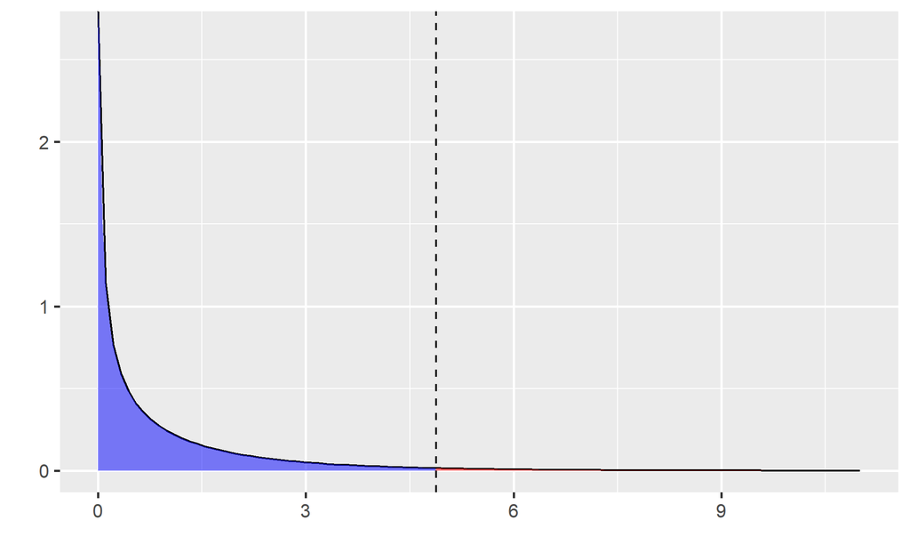

```r
plot(result)
```

# Question 5

- The mean of the population probability for those who Renew_Offer = 0 is **.026**

```r
result <- explore(
  InsuranceRenewalTrain,
  vars = "pred_resp_prob",
  fun = "mean",
  data_filter = "Renew_Offer==0",
  nr = 1
)
summary(result)
```

```
Explore
Data        : InsuranceRenewalTrain
Filter      : Renew_Offer==0
Functions   : mean
Top         : Function

       variable  mean
 pred_resp_prob 0.026
```

```r
# dtab(result) %>% render()
```

- The mean of the population probability for those who Renew_Offer = 1 is **.172**

```r
result <- explore(
  InsuranceRenewalTrain,
  vars = "pred_resp_prob",
  fun = "mean",
  data_filter = "Renew_Offer==1",
  nr = 1
)
summary(result)
```

```
Explore
Data        : InsuranceRenewalTrain
Filter      : Renew_Offer==1
Functions   : mean
Top         : Function

       variable  mean
 pred_resp_prob 0.172
```

```r
# dtab(result) %>% render()
```

- The mean of Odds across all obervations is **.146**

```r
result <- explore(
  InsuranceRenewalTrain,
  vars = "Odds",
  fun = "mean",
  nr = 1
)
summary(result)
```

```
Explore
Data        : InsuranceRenewalTrain
Functions   : mean
Top         : Function

 variable  mean
     Odds 0.146
```

```r
# dtab(result) %>% render()
```

- The LogLikelihood is **-240.018**

```r
result <- explore(
  InsuranceRenewalTrain,
  vars = "LogLikelihood",
  fun = "sum",
  nr = 1
)
summary(result)
```

```
Explore
Data        : InsuranceRenewalTrain
Functions   : sum
Top         : Function

      variable      sum
 LogLikelihood -240.018
```

```r
# dtab(result) %>% render()
```

# Question 6

- 2 deciles have actual response rates higher than 20%

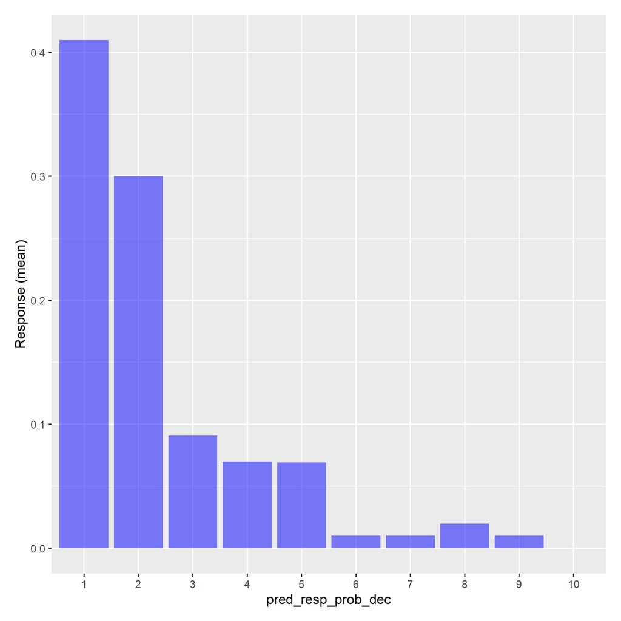

```r
visualize(
  InsuranceRenewalTrain,
  xvar = "pred_resp_prob_dec",
  yvar = "Response",
  type = "bar",
  custom = FALSE
)
```

```r
result <- explore(
  InsuranceRenewalTrain,
  vars = "Response",
  byvar = "pred_resp_prob_dec",
  fun = "mean",
  nr = 10
)
summary(result)
```

```
Explore
Data        : InsuranceRenewalTrain
Grouped by  : pred_resp_prob_dec
Functions   : mean
Top         : Function

 pred_resp_prob_dec variable  mean
                  1 Response 0.410
                  2 Response 0.300
                  3 Response 0.091
                  4 Response 0.070
                  5 Response 0.069
                  6 Response 0.010
                  7 Response 0.010
                  8 Response 0.020
                  9 Response 0.010
                 10 Response 0.000
```

```r
# dtab(result) %>% render()
```

# Question 7

- Sensitivity = 66/99 = 66.67%
- Specificity = 788/901 = 87.46%

```r
result <- explore(
  InsuranceRenewalTrain,
  vars = "pred_resp_prob",
  byvar = c("Response", "pred_resp_prob_rc"),
  fun = "n_obs",
  nr = 4
)
summary(result)
```

```
Explore
Data        : InsuranceRenewalTrain
Grouped by  : Response pred_resp_prob_rc
Functions   : n_obs
Top         : Function

 Response pred_resp_prob_rc       variable n_obs
        0                 0 pred_resp_prob   788
        0                 1 pred_resp_prob   113
        1                 0 pred_resp_prob    33
        1                 1 pred_resp_prob    66
```

```r
# dtab(result) %>% render()
```

- Sensitivity = 41/99 = 41.4%
- Specificity = 842/901 = 93.45%
- If we increase the cutoff to .3, Sensitivity decreases to 41.4%
- If we increase the cutoff to .3, Specificity increases to 93.45%

```r
result <- explore(
  InsuranceRenewalTrain,
  vars = "pred_resp_prob",
  byvar = c("Response", "pred_resp_prob_rcpt3"),
  fun = "n_obs",
  nr = 4
)
summary(result)
```

```
Explore
Data        : InsuranceRenewalTrain
Grouped by  : Response pred_resp_prob_rcpt3
Functions   : n_obs
Top         : Function

 Response pred_resp_prob_rcpt3       variable n_obs
        0                    0 pred_resp_prob   842
        0                    1 pred_resp_prob    59
        1                    0 pred_resp_prob    58
        1                    1 pred_resp_prob    41
```

```r
# dtab(result) %>% render()
```

# Question 8

- The mean for the pred_resp_prob0 test set is **.027**

```r
result <- explore(
  InsuranceRenewalTest,
  vars = "pred_resp_prob0",
  fun = "mean",
  nr = 1
)
summary(result)
```

```
Explore
Data        : InsuranceRenewalTest
Functions   : mean
Top         : Function

        variable  mean
 pred_resp_prob0 0.027
```

```r
# dtab(result) %>% render()
```

# Question 9

- The mean for the pred_resp_prob1 test set is **.168**

```r
result <- explore(
  InsuranceRenewalTest,
  vars = "pred_resp_prob1",
  fun = "mean",
  nr = 1
)
summary(result)
```

```
Explore
Data        : InsuranceRenewalTest
Functions   : mean
Top         : Function

        variable  mean
 pred_resp_prob1 0.168
```

```r
# dtab(result) %>% render()
```

# Question 10

- This number is **300**